# Презентация по лабораторной работе №4

Операционные системы

Лисенков Е.Р.

Российский университет дружбы народов, Москва, Россия

8 марта 2024

## Докладчик

- Лисенков Егор Романович
- студент из группы НКАбд-03-23
- Факультет физико-математических и естественных наук
- Российский университет дружбы народов
- 1132232881@rudn.ru
- https://github.com/erlisenkov

## Цель работы

Научиться правильно работать с репозиториями git.

## Задание

1. Выполнить работу для тестового репозитория.
2. Преобразовать рабочий репозиторий в репозиторий с git-flow и conventional commits.

# Выполнение лабораторной работы

Выполню загрузку из коллекции репозиториев Corp. (рис. [-@fig:001])

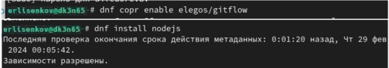

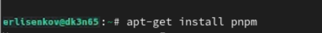

Далее выполню команду pnpm setup. (рис. [-@fig:003])

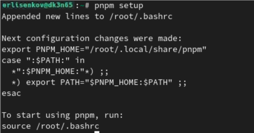

Выполню команду чтобы помочь в форматировании коммитов. (рис. [-@fig:005])

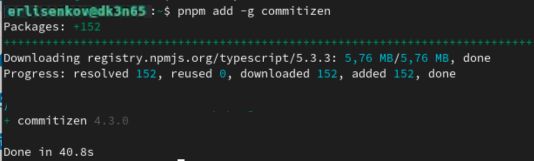

Далее выполняем команду, которая будет создавать логи. (рис. [-@fig:006])

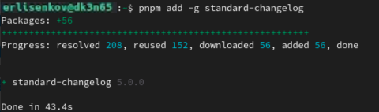

Создадим первый файл README.md и выполним инициализацию репозитория . (рис. [-@fig:008])

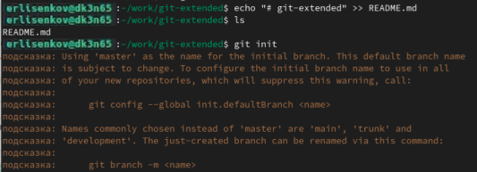

Выполню первый коммит и подключу удалённый репозиторий с помощью консольной команды git remote. Следующим шагом отправим изменения в репозиторий на сайт . (рис. [-@fig:009])

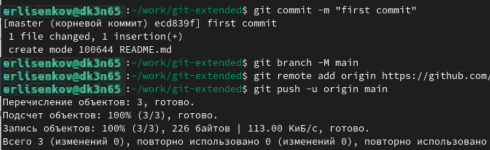

Проверил что на сайте изменения были проведены. Далее создам файл package.json с помощью команды pnpm init. (рис. [-@fig:010])

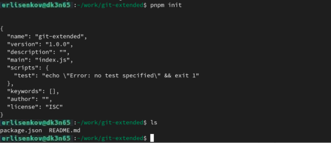

Выполню небольшие изменения в файле. (рис. [-@fig:011])

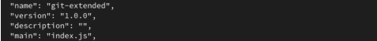

Добавлю новые файлы (git add) и выполню коммит (git cz). (рис. [-@fig:012])

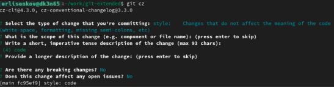

Отправлю изменения. (рис. [-@fig:013])

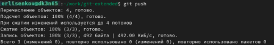

Для дальнейшей работы я инициализирую git-flow с git flow init (Префикс: v). (рис. [-@fig:014])

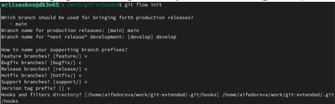

Создам релиз с версией 1.0.0. (рис. [-@fig:018])

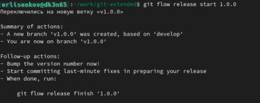

Занесём в индекс журнал изменений. (рис. [-@fig:020])

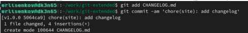

Далее выполняем команды, которые позволят нам положить релизную ветку в основную. Введём сообщения, чтобы программа понимала цели изменения. (рис. [-@fig:021])

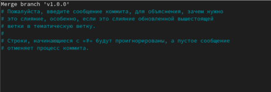

Успешное выполнение! (рис. [-@fig:022])

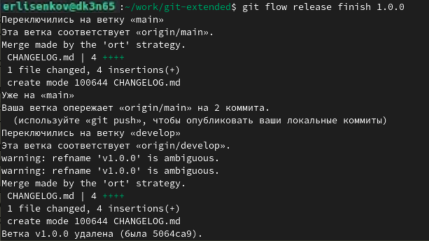

Синхронизирую с git. (рис. [-@fig:023])

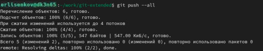

Синхронизируем все поставленные теги. (рис. [-@fig:024])

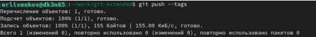

Дополнительно создам ветку для новой функциональности. (рис. [-@fig:026])

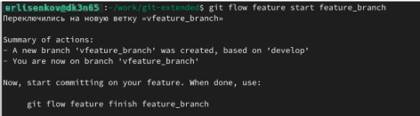

Выполню объединение веток. (рис. [-@fig:027])

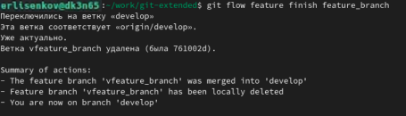

Создам релиз 1.2.3. (рис. [-@fig:028])

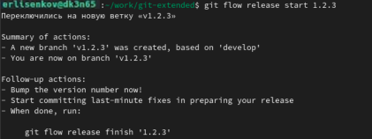

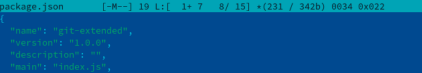

Выполню создание журнала изменений. (рис. [-@fig:030])

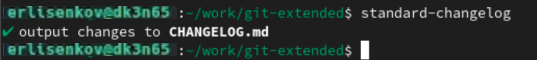

Добавим журнал изменений в индекс. (рис. [-@fig:031])

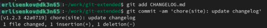

Выполню перенаправление релизной ветки в основную ветку и отвечу на важные вопросы. (рис. [-@fig:032])

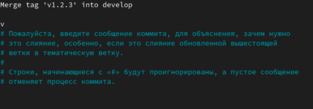

Всё прошло успешно! (рис. [-@fig:033])

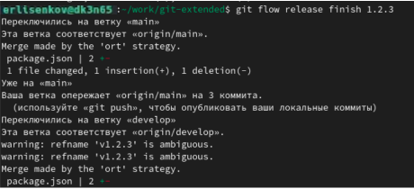

Синхронизация с git. (рис. [-@fig:034])

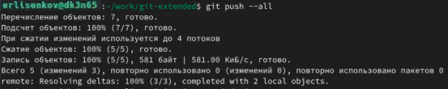

Синхранизация тегов на git&hub. (рис. [-@fig:035])

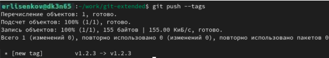

Все изменения были приняты и всё выполнилось!!!! (рис. [-@fig:037])

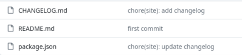

# Выводы

Я получил самые важные знания для работы с git и лучше запомнил материал!

# Спасибо за внимание